# Machine Learning

Paras

3 June 2019

#### Downloading and loading data

```r
fileUrl1 <- "https://d396qusza40orc.cloudfront.net/predmachlearn/pml-training.csv"
download.file(fileUrl1, destfile = "./pml-training.csv", method = "curl")
fileUrl2 <- "https://d396qusza40orc.cloudfront.net/predmachlearn/pml-testing.csv"
download.file(fileUrl2, destfile = "./pml-testing.csv", method = "curl")
TrainData <- read.csv("pml-training.csv")
TestData <- read.csv("pml-testing.csv")
```

Clearly, the data contains lot of NA values and blank clolumns. We will remove these columns as they will not produce any information. The first seven columns give the information about who took the test and the timestamps, hence, we will not take them into our model.

```r
# we will remove those columns having 95% or more entries as NA or blank entries.
remCol <- which(colSums(is.na(TrainData) | TrainData == "") > 0.95*dim(TrainData)[1])
CleanTrainData <- TrainData[ , -remCol]
CleanTrainData <- CleanTrainData[ , -c(1:7)]
dim(CleanTrainData)
```

```
## [1] 19622    53
```

```r
# Repeat the same for TestData
remCol <- which(colSums(is.na(TestData) | TestData == "") > 0.95*dim(TestData)[1])
CleanTestData <- TestData[ , -remCol]
CleanTestData <- CleanTestData[ , -1]
dim(CleanTestData)
```

```
## [1] 20 59
```

#### Partition of training set

After cleaning the data, we now create a partition of the data training set

```r
library(caret)
library(rattle)
set.seed(4321)
inTrain <- createDataPartition(CleanTrainData$classe, p = 0.8, list = FALSE)
training <- CleanTrainData[inTrain, ]
testing <- CleanTrainData[-inTrain, ]
dim(training)
```

```
## [1] 15699    53
```

```r
dim(testing)
```

```
## [1] 3923   53
```

## Building Model

In this section we will test 3 models: classification tree, gradient boosting method and random forest. We will use cross-validation technique to limit the effects of overfitting and improve the efficiency of models. We will use 5-folds to cross validate.

#### Model with Classification Tree

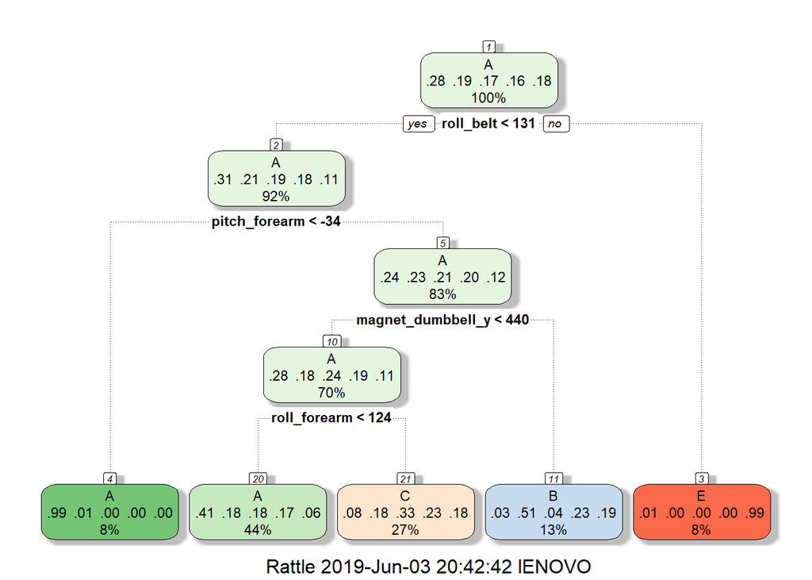

```r
trControl <- trainControl(method = "cv", number = 5)
fit_CT <- train(classe ~ ., data = training, method = "rpart", trControl = trControl)
fancyRpartPlot(fit_CT$finalModel)
```

```r
pred_CT <- predict(fit_CT, newdata = testing)
confMat_CT <- confusionMatrix(testing$classe, pred_CT)
confMat_CT$table
```

```
##           Reference
## Prediction    A    B    C    D    E
##          A 1012   15   86    0    3
##          B  323  256  180    0    0
##          C  329   27  328    0    0
##          D  289  110  244    0    0
##          E  112   90  191    0  328
```

```r
confMat_CT$overall[1]
```

```
## Accuracy
## 0.490441
```

We can see that the accuracy of classification tree model is very low (about 49%). This means that the outcome is poorly predicted by the predictors.

#### Model with Gradient Boosting Method

```r
fit_GBM <- train(classe ~ ., data = training, method = "gbm", trControl = trControl, verbose = FALSE)
print(fit_GBM)
```

```
## Stochastic Gradient Boosting
##
## 15699 samples
##    52 predictor
##     5 classes: 'A', 'B', 'C', 'D', 'E'
##
## No pre-processing
## Resampling: Cross-Validated (5 fold)
## Summary of sample sizes: 12559, 12560, 12560, 12558, 12559
## Resampling results across tuning parameters:
##
##   interaction.depth  n.trees  Accuracy   Kappa
##   1                   50      0.7550170  0.6894648
##   1                  100      0.8231107  0.7761819
##   1                  150      0.8540045  0.8152824
##   2                   50      0.8556600  0.8171594
##   2                  100      0.9073835  0.8828046
##   2                  150      0.9312065  0.9129501
##   3                   50      0.8971914  0.8698489
##   3                  100      0.9420352  0.9266559
##   3                  150      0.9610169  0.9506808
##
## Tuning parameter 'shrinkage' was held constant at a value of 0.1
##
## Tuning parameter 'n.minobsinnode' was held constant at a value of 10
## Accuracy was used to select the optimal model using the largest value.
## The final values used for the model were n.trees = 150,
##  interaction.depth = 3, shrinkage = 0.1 and n.minobsinnode = 10.
```

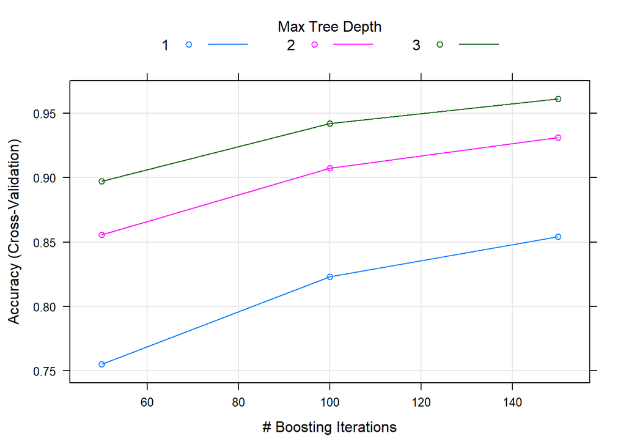

```r
plot(fit_GBM)
```

```r
pred_GBM <- predict(fit_GBM, newdata = testing)
confMat_GBM <- confusionMatrix(testing$classe, pred_GBM)
confMat_GBM$table
```

```
##           Reference
## Prediction    A    B    C    D    E
##          A 1100   11    4    1    0
##          B   25  714   18    2    0
##          C    0   26  643   12    3
##          D    0    3   15  622    3
##          E    1    8    4    8  700
```

```r
confMat_GBM$overall[1]
```

```
##  Accuracy
## 0.9632934
```

The accuracy of Gradient Boosting Method has increased significantly to 96.32% and is considered to be a good fit. We will now check for Random Forest Model.

#### Model With Random Forest Method

```r
fit_RF <- train(classe ~., data = training, method = "rf", trControl = trControl, verbose = FALSE)
print(fit_RF)
```

```
## Random Forest
##
## 15699 samples
##    52 predictor
##     5 classes: 'A', 'B', 'C', 'D', 'E'
##
## No pre-processing
## Resampling: Cross-Validated (5 fold)
## Summary of sample sizes: 12559, 12559, 12559, 12560, 12559
## Resampling results across tuning parameters:
##
##   mtry  Accuracy   Kappa
##    2    0.9925472  0.9905717
##   27    0.9931205  0.9912969
##   52    0.9868780  0.9833998
##
## Accuracy was used to select the optimal model using the largest value.
## The final value used for the model was mtry = 27.
```

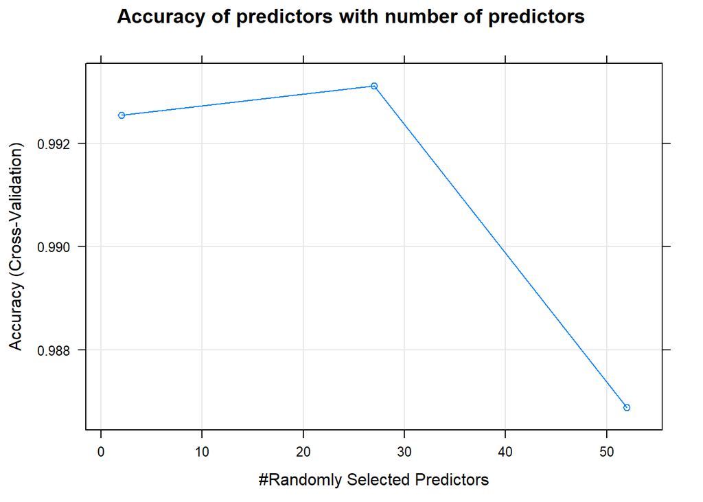

```r
plot(fit_RF, main = "Accuracy of predictors with number of predictors")
```

```r
pred_RF <- predict(fit_RF, newdata = testing)
confMat_RF <- confusionMatrix(testing$classe, pred_RF)
confMat_RF$table
```

```
##           Reference
## Prediction    A    B    C    D    E
##          A 1115    1    0    0    0
##          B    4  754    1    0    0
##          C    0    2  678    4    0
##          D    0    0    6  635    2
##          E    0    1    2    2  716
```

```r
confMat_RF$overall[1]
```

```
##  Accuracy
## 0.9936273
```

The Accuracy of Random Forest Model has increased further to 99.36% using cross-validation of 5 steps and it is the best of the 3 models considered. Moreover, from the plot it can be concluded that optimal number of predictors for maximum accuracy is 27. There is no significant increase of the accuracy with 2 predictors and 27 but the slope decreases more with more than 27 predictors. The accuracy does not decrease very rapidly after 27 predictors, which means that there will be some dependencies between the predictors.

#### Which Predictors are important?

We will now find which predictors mainly affect accuracy

```r
names(fit_RF$finalModel)
```

```
##  [1] "call"            "type"            "predicted"
##  [4] "err.rate"        "confusion"       "votes"
##  [7] "oob.times"       "classes"         "importance"
## [10] "importanceSD"    "localImportance" "proximity"
## [13] "ntree"           "mtry"            "forest"
## [16] "y"               "test"            "inbag"
## [19] "xNames"          "problemType"     "tuneValue"
## [22] "obsLevels"       "param"
```

```r
fit_RF$finalModel$classes
```

```
## [1] "A" "B" "C" "D" "E"
```

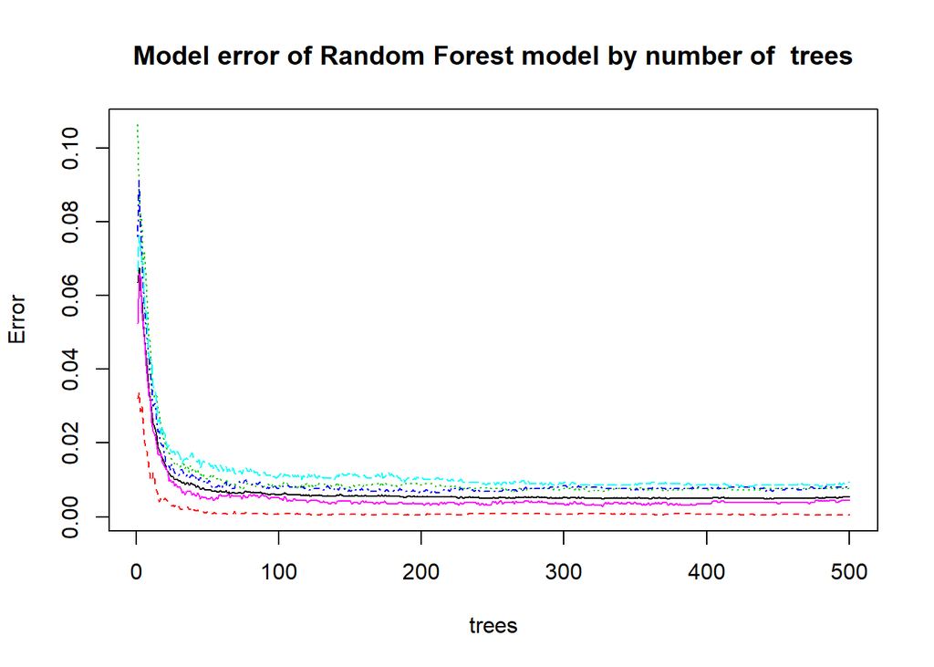

```r
plot(fit_RF$finalModel, main = "Model error of Random Forest model by number of  trees")
```

```r
# compute the most important predictors
MostImpPred <- varImp(fit_RF)
MostImpPred
```

```
## rf variable importance
##
##   only 20 most important variables shown (out of 52)
##
##                      Overall
## roll_belt             100.00
## pitch_forearm          59.06
## yaw_belt               53.89
## pitch_belt             45.31
## magnet_dumbbell_y      43.15
## magnet_dumbbell_z      42.01
## roll_forearm           41.75
## accel_dumbbell_y       20.55
## roll_dumbbell          17.31
## accel_forearm_x        16.21
## magnet_dumbbell_x      15.56
## magnet_forearm_z       14.24
## magnet_belt_z          14.22
## accel_dumbbell_z       13.92
## accel_belt_z           13.36
## total_accel_dumbbell   13.19
## magnet_belt_y          11.84
## gyros_belt_z           10.82
## yaw_arm                10.43
## magnet_belt_x           9.16
```

From the plot, it can be seen that using more than approx 30 number of trees does not decrease the error significantly.

## Conclusion

Applying our model to the test data originally downloaded

```r
finalpred <- predict(fit_RF, newdata = CleanTestData)
finalpred
```

```
##  [1] B A B A A E D B A A B C B A E E A B B B
## Levels: A B C D E
```